# Introduction

Today, we will be movies and TV shows. Many people love to watch shows in their free time. In this notebook, we will take a look at shows and movies on Netflix and try to build a recommendation system using clustering.

**What is clustering you might be asking yourself?**

Clustering is extacly as it sounds. Group data points with other similar data points. Clustering is an unsupervised machine learning method that tries to learn similarities between data points and reveal hidden relationships.

There are many approaches of clustering but let's look at 2:

**Agglomerative Clustering**:

> Agglomerative Clustering starts with the assumption that all points are clusters. In the algorithm, clusters are compared to find how close they are. If clusters are considered to be close then they are merged into a larger cluster. The algorithm ends when the desired number of clusters are formed. An optimal number of clusters for a given data set can be found using a Dendrogram. [(read more)](https://towardsdatascience.com/agglomerative-clustering-and-dendrograms-explained-29fc12b85f23)

**K-Means Clustering**:

> K-means Clustering starts with creating K random center points, called centroids. In the algorithm, data points are compared to the centroid. K-Means Clustering tries to learn most optimal placement for each centroid. [(read more)](https://towardsdatascience.com/understanding-k-means-clustering-in-machine-learning-6a6e67336aa1)

We will be using K-Means Clustering

## Code Setup

```python
# Imports
import numpy as np
import pandas as pd
import seaborn as sns
import math as m
from matplotlib import pyplot as plt
```

```python
# Dataset setup
from google.colab import drive
drive.mount('/content/drive', force_remount=True)

import glob
import os

module_dir = '/content/drive/My Drive/Classes/Computer Science (General)/ITCS 3162/data/project_4'
```

# The Data

We will be using a dataset from [Kaggle](https://www.kaggle.com/datasets/shivamb/netflix-shows).

```python
df_netflix = pd.read_csv(os.path.join(module_dir, 'netflix_titles.csv'))
```

Features of our dataset:

- show_id - id associated with movie in Movies Dataset
- type - Show type (Movie or TV show)
- title - Show Title
- director - Director of show
- cast - Cast of show
- country - Country where show was produced
- date_added - Date added to Netflix
- release_year - Year of release of show
- rating - Maturity Rating
- duration - Minutes long or number of seasons
- listed_in - Genre/Category of movie/show
- description - description of movie/show

```python
df_netflix.head()
```

|  | show_id | type | title | director | cast | country | date_added | release_year | rating | duration | listed_in | description |
| --- | --- | --- | --- | --- | --- | --- | --- | --- | --- | --- | --- | --- |
| 0 | s1 | Movie | Dick Johnson Is Dead | Kirsten Johnson | NaN | United States | September 25, 2021 | 2020 | PG-13 | 90 min | Documentaries | As her father nears the end of his life, filmm... |
| 1 | s2 | TV Show | Blood & Water | NaN | Ama Qamata, Khosi Ngema, Gail Mabalane, Thaban... | South Africa | September 24, 2021 | 2021 | TV-MA | 2 Seasons | International TV Shows, TV Dramas, TV Mysteries | After crossing paths at a party, a Cape Town t... |
| 2 | s3 | TV Show | Ganglands | Julien Leclercq | Sami Bouajila, Tracy Gotoas, Samuel Jouy, Nabi... | NaN | September 24, 2021 | 2021 | TV-MA | 1 Season | Crime TV Shows, International TV Shows, TV Act... | To protect his family from a powerful drug lor... |
| 3 | s4 | TV Show | Jailbirds New Orleans | NaN | NaN | NaN | September 24, 2021 | 2021 | TV-MA | 1 Season | Docuseries, Reality TV | Feuds, flirtations and toilet talk go down amo... |
| 4 | s5 | TV Show | Kota Factory | NaN | Mayur More, Jitendra Kumar, Ranjan Raj, Alam K... | India | September 24, 2021 | 2021 | TV-MA | 2 Seasons | International TV Shows, Romantic TV Shows, TV ... | In a city of coaching centers known to train I... |

```python
df_netflix.shape
```

```
(8807, 12)
```

## Preprocessing

We need to check for null entries and remove a few of the features of data. Also, let's look at shows/movies made in the US only.

```python
# Check null values
df_netflix.isna().sum()
```

```
show_id            0
type               0
title              0
director        2634
cast             825
country          831
date_added        10
release_year       0
rating             4
duration           3
listed_in          0
description        0
dtype: int64
```

```python
# Remove null values
df_netflix = df_netflix.dropna()

# Select only United States
df_netflix = df_netflix[df_netflix['country']  == 'United States']
df_netflix = df_netflix.drop(['country'], axis=1)

df_netflix = df_netflix.reset_index()

# Check that feature was removed
df_netflix.shape
```

```
(1846, 12)
```

Let's also apply pca to our data to reduce the amount of features

```python
from sklearn.decomposition import PCA
from sklearn.preprocessing import LabelEncoder

# Change categorical fields to numerical fields
label_encoder = LabelEncoder()

df_train_obj = df_netflix.select_dtypes("object")
df_train_nonobj = df_netflix.select_dtypes(exclude=['object'])

df_train_obj = df_train_obj.apply(LabelEncoder().fit_transform)

# mash together
df_train = pd.concat([df_train_obj, df_train_nonobj], axis=1)

pca = PCA(n_components=3, random_state=7)
pca_mdl = pca.fit_transform(df_train)
df_pca = pd.DataFrame(pca_mdl)
```

# Training

Before we train our model, we need to identify the optimal amount of clusters for our algorithm to create. One way to do this is the Elbow method.

The Elbow method is a graphical tool that shows us the distortion values for K. While using the elbow method, you want to pick the value that splits the large decreases from the small decreases.

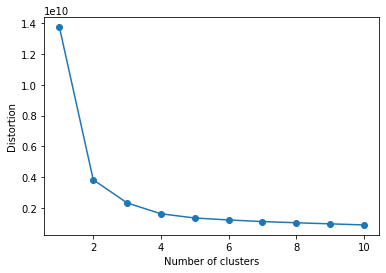

```python
# imports
from sklearn.cluster import KMeans

# calculate distortion for a range of number of cluster
distortions = []

for i in range(1, 11):
  km = KMeans(
    n_clusters=i, init='random',
    n_init=10, max_iter=300,
    tol=1e-04, random_state=0
  )
  km.fit(df_pca)
  distortions.append(km.inertia_)


# plot
plt.plot(range(1, 11), distortions, marker='o')
plt.xlabel('Number of clusters')
plt.ylabel('Distortion')
plt.show()
```

Let's pick 4 for our K value

```python
# Our model
km = KMeans(
    n_clusters=4, init='random',
    n_init=10, max_iter=300,
    tol=1e-04, random_state=0
)
y_km = km.fit_predict(df_pca)
```

# Modelling

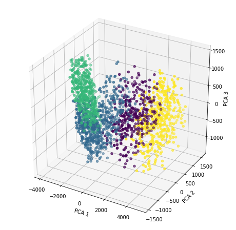

```python
#Using 4 clusters again, visualize for 3 dimensions
fig = plt.figure(figsize=(8,8))
ax = fig.add_subplot(projection = '3d')

x = df_pca[0]
y = df_pca[1]
z = df_pca[2]

ax.set_xlabel("PCA 1")
ax.set_ylabel("PCA 2")
ax.set_zlabel("PCA 3")

ax.scatter(x, y, z, c = y_km)

plt.show()
```

We can see that there are 4 distinct groups from our K-means Clustering model. Unfortunately, since we used PCA, these groups are not human readable. Let's try again with our original dataset.

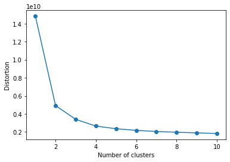

```python
# calculate distortion for a range of number of cluster
distortions = []

for i in range(1, 11):
  km = KMeans(
    n_clusters=i, init='random',
    n_init=10, max_iter=300,
    tol=1e-04, random_state=0
  )
  km.fit(df_train)
  distortions.append(km.inertia_)


# plot
plt.plot(range(1, 11), distortions, marker='o')
plt.xlabel('Number of clusters')
plt.ylabel('Distortion')
plt.show()
```

Let's use 4 for our original data too

```python
# Our model
km = KMeans(
    n_clusters=4, init='random',
    n_init=10, max_iter=300,
    tol=1e-04, random_state=0
)
y_km = km.fit_predict(df_train)
```

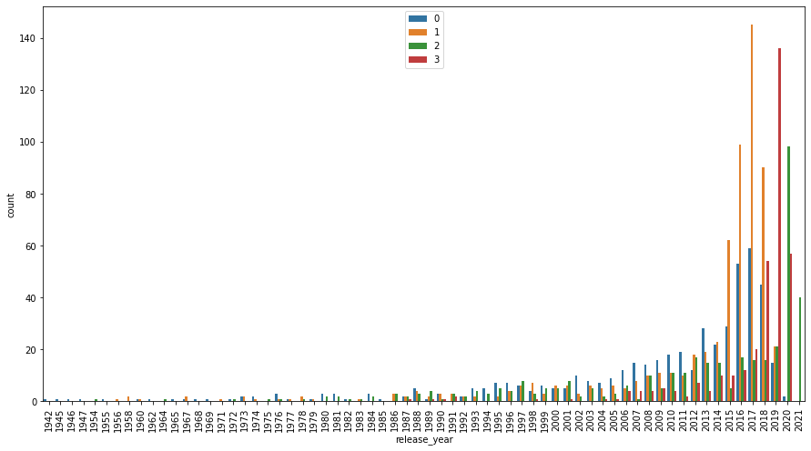

```python
# Model it
sns.countplot(x="release_year", data=df_train, hue=y_km)
plt.xticks(rotation=90)
plt.gcf().set_size_inches(15, 8)
```

Let's test our K-Means Clustering algorithm as a reccomendation system.

```python
# Grab random entry from our data set
sample = df_train.sample()

# rerun to generate different samples
sample
```

|  | show_id | type | title | director | cast | date_added | rating | duration | listed_in | description | index | release_year |
| --- | --- | --- | --- | --- | --- | --- | --- | --- | --- | --- | --- | --- |
| 1391 | 1320 | 0 | 808 | 43 | 919 | 406 | 1 | 136 | 181 | 1170 | 7172 | 2006 |

```python
df_train.shape
```

```
(1846, 12)
```

```python
# find out what cluster it belongs to
label = y_km[sample.index[0]]

# pick random movie from cluster
recommend_show = df_train.loc[np.random.choice(np.where(y_km == label)[0])]

# Display our selection
df_netflix.iloc[recommend_show.name]
```

```
index                                                        7520
show_id                                                     s7521
type                                                        Movie
title                                                Mr. Woodcock
director                                          Craig Gillespie
cast            Billy Bob Thornton, Seann William Scott, Ethan...
date_added                                      September 1, 2019
release_year                                                 2007
rating                                                      PG-13
duration                                                   88 min
listed_in                                                Comedies
description     When a self-help author learns that his mother...
Name: 1477, dtype: object
```

# Conclusion

We Can see that our basic recommender system using K-Means Clustering is working. We have accomplished what we set out to do. In the future, we could improve the system by using some natural language processing and further breaking down relationships between data features.

Today we learned about clustering algorithms and experimented with K-Means Clustering. We were able to build a simple recommender system using our clusters. Below is a function showcasing our recommender:

```python
def recommender():
  # Grab random entry from our data set
  sample = df_train.sample()
  sample_netflix = df_netflix.iloc[sample.index[0]]

  # find out what cluster it belongs to
  label = y_km[sample.index[0]]

  # pick random movie from cluster
  recommend_show = df_train.loc[np.random.choice(np.where(y_km == label)[0])]

  # Display our selection
  return sample_netflix, df_netflix.iloc[recommend_show.name], label


results = recommender()

print('Sample Movie Watched:')
print('---------------------')
print(results[0])

print('\nCluster: %s' % results[2])

print('\nRecommendation:')
print('-----------------')
print(results[1])
```

```
Sample Movie Watched:
---------------------
index                                                        7986
show_id                                                     s7987
type                                                        Movie
title                                          Sex and the City 2
director                                     Michael Patrick King
cast            Sarah Jessica Parker, Kim Cattrall, Cynthia Ni...
date_added                                        January 1, 2021
release_year                                                 2010
rating                                                          R
duration                                                  146 min
listed_in                       Comedies, Dramas, Romantic Movies
description     Best friends Carrie, Miranda, Samantha and Cha...
Name: 1603, dtype: object

Cluster: 0

Recommendation:
-----------------
index                                                        8380
show_id                                                     s8381
type                                                        Movie
title                                              The Lake House
director                                        Alejandro Agresti
cast            Keanu Reeves, Sandra Bullock, Dylan Walsh, Sho...
date_added                                      September 1, 2019
release_year                                                 2006
rating                                                         PG
duration                                                   98 min
listed_in               Dramas, Romantic Movies, Sci-Fi & Fantasy
description     A lonely doctor begins writing letters to the ...
Name: 1726, dtype: object
```

# Sources

- [Source Code](https://colab.research.google.com/drive/1yjW_5xQ2J5b_zbWS48tmSIoTEc9P5OFq?usp=sharing)
- [Dataset](https://www.kaggle.com/datasets/shivamb/netflix-shows)
- [Agglomerative Clustering](https://towardsdatascience.com/agglomerative-clustering-and-dendrograms-explained-29fc12b85f23)
- [K-Means Clustering](https://towardsdatascience.com/understanding-k-means-clustering-in-machine-learning-6a6e67336aa1)